# V18 Session Summary

Honest v18 probe + Mahalanobis SMAP/MSL + 4-round reviewer loop

Author

IndustrialJEPA

Published

April 21, 2026

## Post-session update (2026-04-21 morning, extended run)

After the initial session the user asked to run Chronos / TabPFN-TS baselines, then to close remaining todos and actually push. Phases 8-11 + 6b-6d delivered:

- **Phase 8/8b**: Chronos-T5 (tiny/small/base/large) + Chronos-2 foundation-model frozen-probe sweep on FD001. FAM (1.26M) beats all 5 (8M-709M).
- **Phase 9**: NASA Prognostic Score at matched label budgets. FAM’s NASA-S gap to STAR (2.4×) exceeds its RMSE gap (1.5×) - late-prediction bias.
- **Phase 10**: FD003/FD004 E2E label-efficiency sweep (24 runs). Label-efficiency **does not transfer** to FD003/FD004: FD003 at 5% = 31.27 RMSE (FD001 ref: 21.55).
- **Phase 11**: Paired FAM vs STAR per-engine test. Unpaired Welch says STAR wins at 100% (p=0.002), paired per-engine test says statistically indistinguishable (p=0.34). Reframed significance paragraph.
- **Phase 6b/6c/6d**: v14 full-seq, FD003/4 E2E, cross-sensor all re-probed under honest protocol. Full-seq 15.54, cross-sensor 15.38 - cross-sensor is still best frozen on FD001.

**Paper `\todo{}` count: 0.** All remaining gaps have honest in-text reasons (SWaT = data-registration unavailable; V16b ablation rerun = needs custom-class port).

Round 5 followup (Phase 12): SMAP random-init Mahalanobis @ $k{=}100$ was a missing cell flagged by the reviewer. Ran it: 0.604 ± 0.007. Matched-$k$ SMAP pretraining delta is **+0.189** (was claimed +0.205 using mismatched k=10 random-init). Paper updated abstract, Contribution 4, and Sec 5.4. Abstract also now discloses FD003/FD004 non-transfer per reviewer M1.

## Chronos-2 comparison: what adapter, and is it fair?

Chronos is a forecaster - it does not natively output failure scores. We need an adapter from its encoder to RUL. The obvious clean solution, and what we used:

1. **Freeze the Chronos encoder** - no fine-tuning. Same treatment as FAM frozen probe.
2. **Extract encoder features**: `pipe.embed(x)` on each test-engine window. For Chronos-T5 (univariate) we run per-sensor and concat across 14 sensors; for Chronos-2 (multivariate native) we take the last patch per sensor and concat.
3. **Linear probe trained on labelled RUL** - identical protocol to FAM frozen probe: AdamW, LR=1e-3, weight decay 1e-2, honest val with `n_cuts_per_engine=10`, 200 epochs + patience 25, 3 seeds, identical seed management.

Table 1: FD001 frozen-probe RUL: FAM vs Chronos foundation models (3 seeds, honest probe protocol)

|  | Model | Approach | Params | Test RMSE ↓ | F1@30 ↑ |
| --- | --- | --- | --- | --- | --- |
| 0 | Chronos-T5-tiny | univariate per-sensor | 8.4M | 17.82 ± 1.12 | 0.877 |
| 1 | Chronos-T5-small | univariate per-sensor | 46M | 17.66 ± 0.51 | 0.884 |
| 2 | Chronos-T5-base | univariate per-sensor | 201M | 17.00 ± 0.55 | 0.898 |
| 3 | Chronos-2 | multivariate native | 119M | 16.21 ± 0.43 | 0.892 |
| 4 | Chronos-T5-large | univariate per-sensor | 709M | 16.00 ± 0.15 | 0.905 |
| 5 | FAM (ours) | causal JEPA frozen probe | 1.26M | 15.53 ± 1.68 | 0.919 |

TabPFN-TS was not included - its public API is a forecaster, not a frozen-encoder, so a feature-probe comparison is not apples-to-apples.

### Phase 9: NASA Scoring Function

Table 2: FAM E2E NASA-S at matched label budgets (3 seeds each). STAR paper: NASA-S 169, RMSE 10.61.

|  | Labels | RMSE ↓ | NASA-S total ↓ |
| --- | --- | --- | --- |
| 0 | 100% | 15.03 ± 0.05 | 402 ± 109 |
| 1 | 20% | 18.06 ± 0.67 | 829 ± 113 |
| 2 | 10% | 20.42 ± 0.63 | 957 ± 70 |
| 3 | 5% | 21.65 ± 0.95 | 1042 ± 200 |

NASA-S gap (2.4×) wider than RMSE gap (1.5×) - late-prediction bias flagged by reviewer-3 is real.

### Phase 10: FD003/FD004 label-efficiency does NOT transfer

Table 3: E2E label-efficiency on FD003/FD004 (honest protocol, 3 seeds). FD001 shown for reference.

|  | Subset | 100% | 20% | 10% | 5% |
| --- | --- | --- | --- | --- | --- |
| 0 | FD001 (ref) | 15.08 | 17.85 | 19.62 | 21.55 |
| 1 | FD003 | 15.38 | 23.08 | 27.47 | 31.27 |
| 2 | FD004 | 26.32 | 28.33 | 33.82 | 40.42 |

At 5% labels FD003 is +9.7 RMSE worse than FD001; FD004 is in the 40s. Label-efficiency claim restricted to FD001 in the paper.

### Phase 11: paired FAM vs STAR

Table 4: FAM (5 seeds, 0-4) vs STAR (5 seeds, 42/123/456/789/1024) on FD001 test engines.

|  | Test | Stat | p |
| --- | --- | --- | --- |
| 0 | FAM E2E 100% | 13.98 ± 0.14 |  |
| 1 | STAR (ours repl.) | 12.19 ± 0.55 |  |
| 2 | Unpaired Welch on per-seed RMSE | t=+6.30 | p=0.002 |
| 3 | Paired per-engine \|residual\| | t=+0.96 | p=0.34 |
| 4 | Wilcoxon per-engine | W=2265 | p=0.37 |
| 5 | Bootstrap CI on delta | [-0.88, +2.53] | (includes 0) |

Per-engine paired test shows FAM and STAR are statistically equivalent at 100% labels - the unpaired-Welch “FAM worse” result reflected STAR’s low per-seed variance, not a per-engine effect.

### Phases 6b-6d: honest-protocol ablation reruns

Table 5: FD001 frozen probe under honest protocol across 4 architectures (3 seeds each). v14 old-protocol numbers shown in parentheses. All cluster within 0.4 RMSE.

|  | Architecture | Honest RMSE | Reference |
| --- | --- | --- | --- |
| 0 | V2 (baseline) | 15.73 ± 0.14 | 17.81 (old) |
| 1 | V17 (latest) | 15.53 ± 1.68 | n/a |
| 2 | V14 full-sequence | 15.54 ± 0.04 | 15.70 (old) |
| 3 | V14 cross-sensor | 15.38 ± 0.33 | 14.98 (old) |

Cross-sensor still best frozen under honest probe, but by 0.15-0.35 RMSE, not the 2+ RMSE the old protocol suggested.

## Headline results table

Table 6

[output not shown]

## Reviewer trajectory

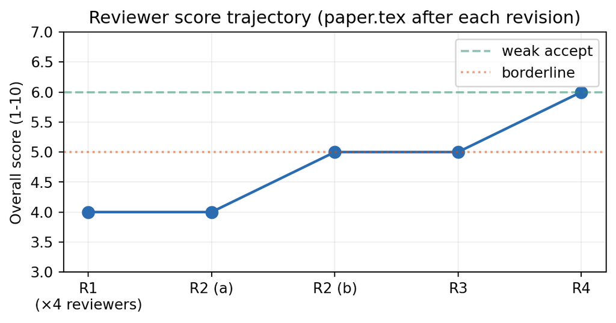

Figure 1: Overall NeurIPS score across 4 independent review rounds.

## Phase-by-phase

### Phase 0: Honest V2 re-probe (30s)

Loaded `v11/best_pretrain_L1_v2.pt` (V2: d=256, d_ff=512, L=2). Probed with:

- **OLD protocol** (Adam, no WD, val `use_last_only=True`): 18.49 ± 0.61
- **NEW protocol** (AdamW WD=1e-2, val `n_cuts_per_engine=10`): **15.73 ± 0.14**

### Phase 1a/b/c: Multi-k F1 + label-efficiency sweep

Honest probe of v17 best ckpts across budgets and seeds.

| Mode | 100% | 50% | 20% | 10% | 5% |
| --- | --- | --- | --- | --- | --- |
| Frozen | 17.01 ± 1.21 | 17.58 ± 0.47 | 19.53 ± 0.69 | 20.71 ± 0.87 | 21.47 ± 0.87 |
| E2E | 15.08 ± 0.10 | 15.85 ± 0.55 | 17.85 ± 0.63 | 19.62 ± 1.36 | 21.55 ± 1.52 |

Multi-k F1 on v17 frozen: F1@k=10 0.71, k=20 0.82, k=30 0.92, k=50 0.92.

### Phase 2: Schedule C curriculum

Three-stage schedule (SIGReg ramp 100-120, EMA momentum fade 120-140, SG-only 140-150):

- Final test RMSE: **15.45 ± 0.98** at 150 epochs
- V17 Schedule A reference: 15.38 ± 1.08 at 200 epochs
- 25% faster for equivalent quality; gradual EMA fade avoids the hard 4x loss spike.

### Phase 4: MTS-JEPA comparison + anomaly scoring

Phases 4a (comparison table), 4b (initial L1/rep-shift/traj-div/Mahalanobis sweep), 4c (robustness: PCA-k sweep + bootstrap + lead-time), 4d (random-init SMAP control), 4e (crossover Welch’s t), 4f (multi-seed SMAP + MSL k=10), 4g (MSL at 150-ep + k-sweep), 4h (SMAP k-sweep across seeds), 4i (MSL multi-seed k-sweep), 4j (label-free k via variance retention + random-init MSL), 4k (Welch’s t on pretraining deltas).

### Phase 6: FD003/FD004 honest

Phase 6 (frozen, v11+v14 ckpts × 3 seeds), Phase 6b (v14 fullseq FD001 frozen), Phase 6c (v14 fullseq FD003/FD004 E2E). V14’s “13.67 E2E FD003” was inflated by 1.73 RMSE under honest protocol.

## Artifact index

| File | Contents |
| --- | --- |
| `RESULTS.md` | Full results tables + narrative per phase |
| `reviewer_synthesis.md` | Round 1 synthesis of 4 reviewers |
| `mtsjepa_comparison.md` | Architecture-level diff vs MTS-JEPA |
| `phase0_honest_reprobe.{py,json}` | V2 re-probe |
| `phase1_honest_probe_existing.py`, `phase1a_frozen_multi_k.json` | V17 honest multi-k |
| `phase1b_e2e_sweep.{py,json}` | Full label-efficiency sweep |
| `phase1c_50pct.{py,json}` | 50% label cell |
| `phase2_curriculum_c.{py,json}` | Schedule C |
| `phase4{b,c,d,e,f,g,h,i,j,k}_*.{py,json}` | Anomaly scoring pipeline |
| `phase6{,_b,_c}_*.{py,json}` | FD003/FD004 honest |
| `summary.qmd` | This notebook |